# Assignment03 VIS

## Q2

Number and proportion of drinking fountains (B) within 0.25 miles or 1320 ft of WiFi hotspots (A).

I am having the same issue here as with Question 1. My `fountains_join` somehow has 8 more observations than the original `fountains`. I tried to look up functions that would return the discrepancies between the two tables, but was running out of time trying to troubleshoot.

```r
wifi_buffer <- st_buffer(wifi, dist = 1320) %>%
  st_union()

fountains_wifi <- fountains[wifi_buffer,]

fountains_join <- st_join(fountains, fountains_wifi) %>%
  mutate(near_wifi = !is.na(system.y))
```

```r
# Number of fountains near Wifi hotspots.
sum(fountains_join$near_wifi)
```

```
## [1] 1828
```

```r
# Number of fountains total
length(fountains_join$near_wifi)
```

```
## [1] 3128
```

```r
# or is it
nrow(fountains)
```

```
## [1] 3120
```

```r
# Proportion
sum(fountains_join$near_wifi) / length(fountains_join$near_wifi)
```

```
## [1] 0.584399
```

```r
# or is it
sum(fountains_join$near_wifi) / nrow(fountains)
```

```
## [1] 0.5858974
```

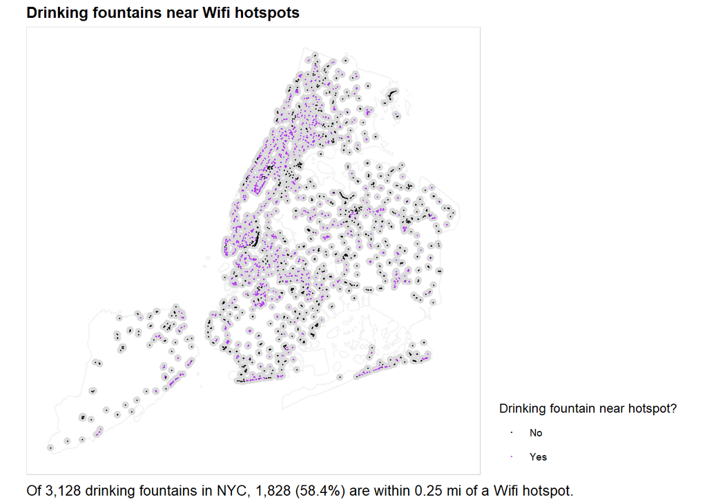

```r
ggplot() +
  geom_sf(data = nyc,
          fill = NA,
          color = "gray95") +
  geom_sf(data = fountains_buffer,
          color = NA,
          fill = "gray80",
          alpha = 0.7) +
  geom_sf(data = fountains_join,
          aes (color = near_wifi),
          size = 0.2) +
  scale_color_manual(name = "Drinking fountain near hotspot?",
                     values = c("black","darkorchid2"),
                     labels = c("No","Yes")) +
  labs(title = "Drinking fountains near Wifi hotspots",
       caption = "Of 3,128 drinking fountains in NYC, 1,828 (58.4%) are within 0.25 mi of a Wifi hotspot.") +
  theme_map() +
  theme(panel.background = element_rect(color = "gray88")) +
    theme(legend.position = "right",
        legend.background = element_rect(fill = alpha("white",0.5)),
        panel.background = element_rect(fill = NA,
                                        color = "gray88"),
        plot.title = element_text(face = "bold"),
        plot.caption = element_text(hjust = 0, size = 10))
```

## Q6

Number and proportion of Wifi hotspots (A) within Parks (C).

```r
# Adding a column with each row showing # of Wifi hotspots that fall in that park.
parks <- parks %>%
  mutate(num_wifi = lengths(st_covers(parks,wifi)))

# Number of Wifi hotspots within Parks
sum(parks$num_wifi)
```

```
## [1] 416
```

```r
# Number of Wifi hotspots
nrow(wifi)
```

```
## [1] 3319
```

```r
# Proportion:
sum(parks$num_wifi) / nrow(wifi)
```

```
## [1] 0.125339
```

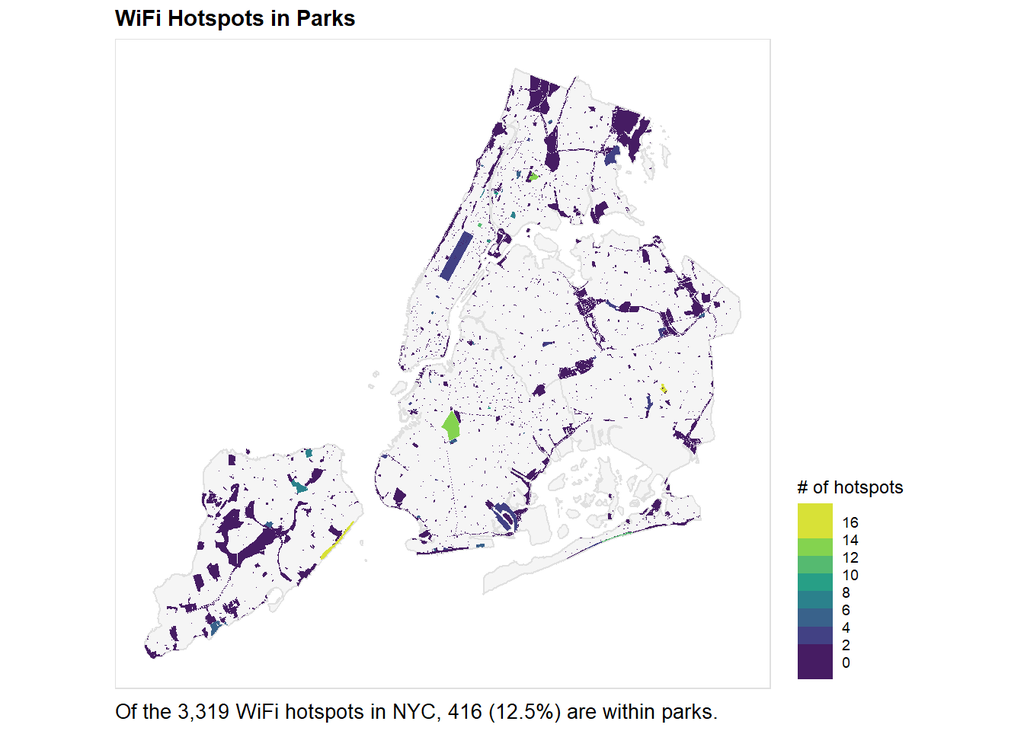

```r
ggplot(parks) +
  geom_sf(data = nyc,
          color = "gray88",
          fill = "gray96") +
  geom_sf(aes(fill = num_wifi),
          color = NA) +
  scale_fill_viridis_b(name = "# of hotspots",
                       breaks = seq(0, 16, by = 2)) +
  labs(title = "WiFi Hotspots in Parks",
       caption = "Of the 3,319 WiFi hotspots in NYC, 416 (12.5%) are within parks.") +
  theme_map() +
  theme(legend.position = "right",
        legend.background = element_rect(fill = alpha("white",0.5)),
        panel.background = element_rect(fill = NA,
                                        color = "gray88"),
        plot.title = element_text(face = "bold"),
        plot.caption = element_text(hjust = 0, size = 10))
```

## Q7

Number and proportion of Wifi hotspots (A) within Plazas (D).

```r
plazas <- plazas %>%
  mutate(num_wifi = lengths(st_covers(plazas,wifi)))

# Number of Wifi hotspots within Parks
sum(plazas$num_wifi)
```

```
## [1] 17
```

```r
# Number of Wifi hotspots
nrow(wifi)
```

```
## [1] 3319
```

```r
# Proportion
sum(plazas$num_wifi) / nrow(wifi)
```

```
## [1] 0.005122025
```

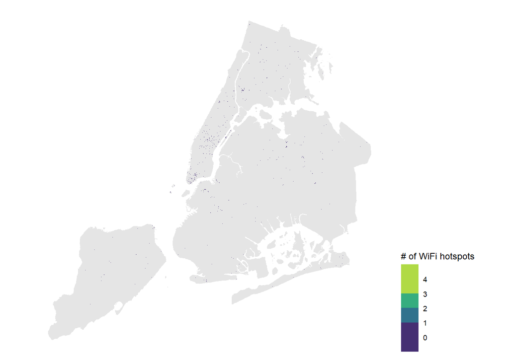

```r
# This plot is not that great. Please see next one, where I applied st_centroid().

ggplot(plazas) +
  geom_sf(data = nyc,
          color = NA) +
  geom_sf(aes(fill = num_wifi),
          color = NA) +
  scale_fill_viridis_b(name = "# of WiFi hotspots",
                       breaks = seq(0, 4, by = 1)) +
  theme_map() +
  theme(legend.position = "right")
```

```r
# Thanks Carole for suggesting I apply st_centroid so I can do a proportional dot symbol plot.
plazas2 <- st_centroid(plazas)
# Number of Wifi hotspots within Parks
sum(plazas2$num_wifi)
```

```
## [1] 17
```

```r
# Number of Wifi hotspots
nrow(wifi)
```

```
## [1] 3319
```

```r
# Proportion
sum(plazas2$num_wifi) / nrow(wifi)
```

```
## [1] 0.005122025
```

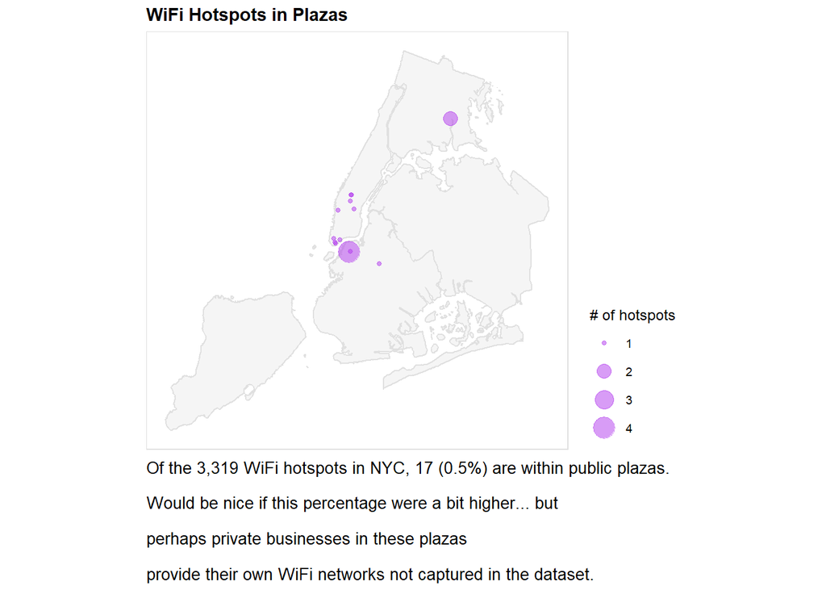

```r
# I had to filter out the 0 hotspots, otherwise the plot would show purple dots for 0 as well (is it supposed to?)
ggplot(plazas2 %>% filter(!num_wifi == 0)) +
  geom_sf(data = nyc,
          color = "gray88",
          fill = "gray96") +
  geom_sf(aes(size = num_wifi),
          color = "darkorchid2",
          alpha = 0.5) +
  scale_size_continuous(name = "# of hotspots",
                        breaks = seq(1, 4, by = 1)) +
  labs(title = "WiFi Hotspots in Plazas",
       caption = "Of the 3,319 WiFi hotspots in NYC, 17 (0.5%) are within public plazas.
       \nWould be nice if this percentage were a bit higher... but
       \nperhaps private businesses in these plazas
       \nprovide their own WiFi networks not captured in the dataset.") +
  theme_map() +
  theme(legend.position = "right",
        legend.background = element_rect(fill = alpha("white",0.5)),
        panel.background = element_rect(fill = NA,
                                        color = "gray88"),
        plot.title = element_text(face = "bold"),
        plot.caption = element_text(hjust = 0, size = 10))
```

## Q8

Number and proportion of drinking fountains (B) within plazas (D). (I ended up not plotting drinking fountains within parks because I’m pretty sure the dataset of the drinking fountains is from NYC Parks and Rec. and is of their fountains only.)

```r
plazas <- plazas %>%
  mutate(num_fountains = lengths(st_covers(plazas,fountains)))

# Number of fountains within Plazas
sum(plazas$num_fountains)
```

```
## [1] 7
```

```r
# Number of fountains
nrow(fountains)
```

```
## [1] 3120
```

```r
# Proportion
sum(plazas$num_fountains) / nrow(fountains)
```

```
## [1] 0.00224359
```

```r
plazas2 <- st_centroid(plazas)
```

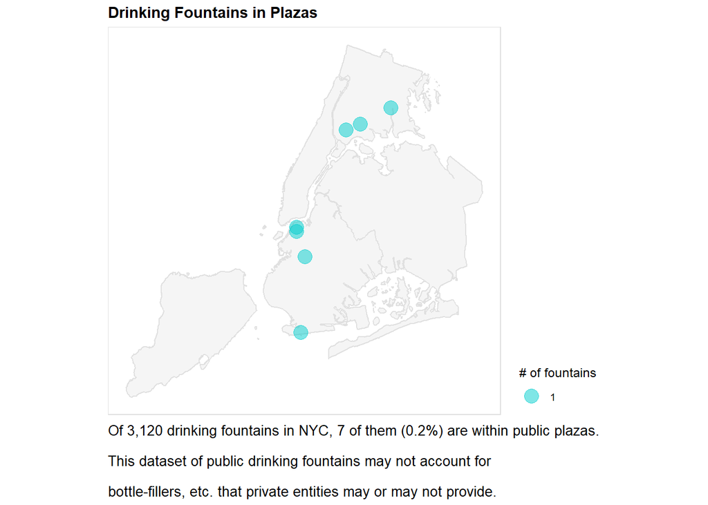

```r
ggplot(plazas2 %>% filter(!num_fountains == 0)) +
  geom_sf(data = nyc,
          color = "gray88",
          fill = "gray96") +
  geom_sf(aes(size = num_fountains),
          color = "cyan3",
          alpha = 0.5) +
  scale_size_continuous(name = "# of fountains",
                        breaks = seq(1, 4, by = 1)) +
  labs(title = "Drinking Fountains in Plazas",
       caption = "Of 3,120 drinking fountains in NYC, 7 of them (0.2%) are within public plazas.
       \nThis dataset of public drinking fountains may not account for
       \nbottle-fillers, etc. that private entities may or may not provide.") +
  theme_map() +
  theme(legend.position = "right",
        legend.background = element_rect(fill = alpha("white",0.5)),
        panel.background = element_rect(fill = NA,
                                        color = "gray88"),
        plot.title = element_text(face = "bold"),
        plot.caption = element_text(hjust = 0, size = 10))
```

## Q11

Number and proportion of Plazas (D) that contain Wifi hotspots (A).

```r
plazas <- plazas %>%
  mutate(has_wifi = num_wifi > 0)

# Plazas with Wifi hotspots
sum(plazas$has_wifi)
```

```
## [1] 13
```

```r
# Number of Plazas
nrow(plazas)
```

```
## [1] 1360
```

```r
# Proportion
sum(plazas$has_wifi) / nrow(plazas)
```

```
## [1] 0.009558824
```

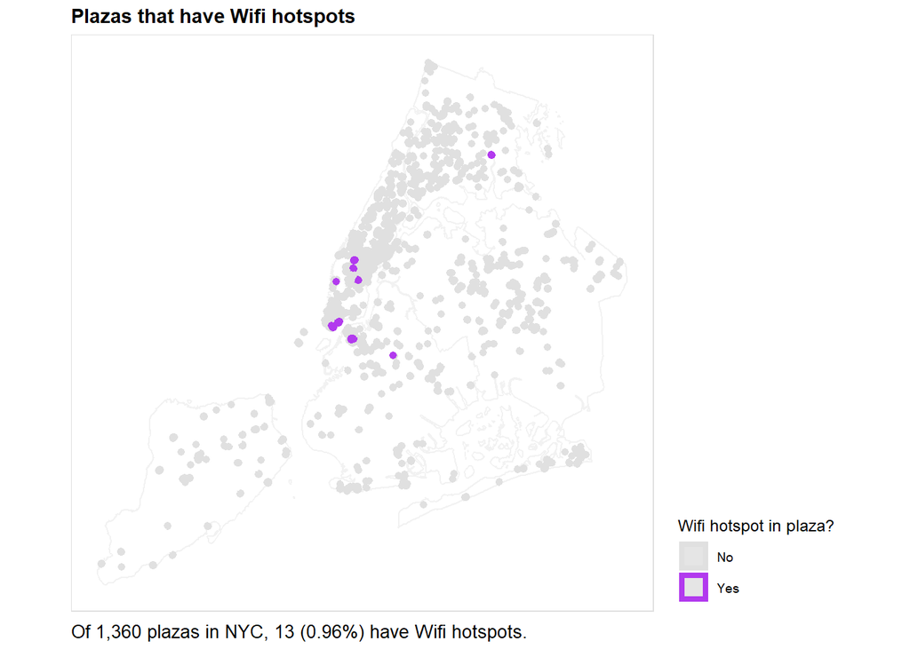

```r
ggplot()+
  geom_sf(data = nyc,
          fill = NA,
          color = "gray95") +
  geom_sf(data = plazas,
          aes (color = has_wifi),
          size = 2) +
  scale_color_manual(name = "Wifi hotspot in plaza?",
                     values = c("gray88","darkorchid2"),
                     labels = c("No","Yes")) +
  labs(title = "Plazas that have Wifi hotspots",
       caption = "Of 1,360 plazas in NYC, 13 (0.96%) have Wifi hotspots.") +
  theme_map() +
  theme(panel.background = element_rect(color = "gray88")) +
    theme(legend.position = "right",
        legend.background = element_rect(fill = alpha("white",0.5)),
        panel.background = element_rect(fill = NA,
                                        color = "gray88"),
        plot.title = element_text(face = "bold"),
        plot.caption = element_text(hjust = 0, size = 10))
```

## Q14

Number and proportion of Parks (C) that have overlapping Plazas (D).

I don’t know if the following map is effective – I’m running into the issue where the polygons are too small for a meaningful map to be made using `aes(fill = parks)`, so I tried to make a Dorling cartogram instead. However, I think there is a false impression that all parks that fall within the confines of the dots have overlapping plazas, when really it’s just 1 park that has 1 plaza.

I tried to change the size of the Dorling dots but I’m not sure if I can, because I’m supplying a polygonal dataset… maybe I have to turn the polygons into points using `st_centroid()` first?

```r
# Applying st_overlaps
parks <- parks %>%
  mutate(num_plazas = lengths(st_overlaps(parks,plazas))) %>%
  mutate(has_plazas = num_plazas > 0)

# Number of Parks that overlap Plazas
sum(parks$has_plazas)
```

```
## [1] 9
```

```r
# Number of Parks
nrow(parks)
```

```
## [1] 12491
```

```r
# Proportion
sum(parks$has_plazas) / nrow(parks)
```

```
## [1] 0.0007205188
```

```r
parks_dor <- parks %>%
  cartogram_dorling("num_plazas")
```

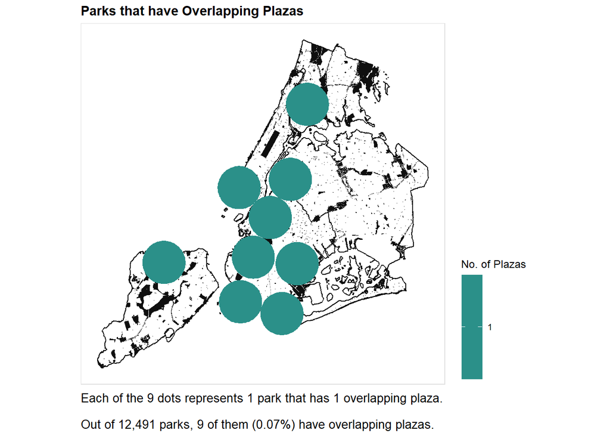

```r
ggplot()+
  geom_sf(data = nyc,
          color = "gray6",
          fill = NA) +
  geom_sf(data = parks,
          fill = "gray6",
          color = NA) +
  geom_sf(data = parks_dor,
          aes(fill = num_plazas),
          color = NA) +
  scale_fill_viridis_c(name = "No. of Plazas",
                       breaks = seq(0, 1, by = 1)) +
  labs(title = "Parks that have Overlapping Plazas",
       caption = "Each of the 9 dots represents 1 park that has 1 overlapping plaza.
                  \nOut of 12,491 parks, 9 of them (0.07%) have overlapping plazas.") +
  theme_map() +
  theme(legend.position = "right",
        legend.background = element_rect(fill = alpha("white",0.5)),
        panel.background = element_rect(fill = NA,
                                        color = "gray88"),
        plot.title = element_text(face = "bold"),
        plot.caption = element_text(hjust = 0, size = 10))
```